# Preguntas_Exploratorias

Irving, Chuy

2025-01-30

## Preguntas

Después de haber concluido las exploración de las variables es momento de empezar a operar con preguntas directas para tener un mayor acercamiento a la base de datos.

### 2. ¿Cuáles son las 10 películas que más ingresos tuvieron?

10 películas con mayores ingresos

| title | revenue |
| --- | --- |
| Avatar | 2847246203 |
| Avengers: Endgame | 2797800564 |
| Titanic | 2187463944 |
| Star Wars: The Force Awakens | 2068223624 |
| Avengers: Infinity War | 2046239637 |
| Jurassic World | 1671713208 |
| The Lion King | 1667635327 |
| Spider-Man: No Way Home | 1631853496 |
| The Avengers | 1518815515 |
| Furious 7 | 1515047671 |

### 4.¿Cuál es la peor película de acuerdo a los votos de todos los usuarios?

Top películas peor puntuadas

| title | voteCount | voteAvg |
| --- | --- | --- |
| El silencio | 1 | 2.0 |
| 극장판 레이디버그: 미라클 스톤의 비밀 | 1 | 2.0 |
| Sing Along | 1 | 2.0 |
| Tar Pits Film | 1 | 2.0 |
| Captain America: Civil War Reenactors | 1 | 2.0 |
| Los cazafantasmas de Petatiux | 1 | 2.0 |
| One Crazy Summer: A Look Back at Gravity Falls | 1 | 2.0 |
| Scream for Summer | 1 | 2.0 |
| La Cantera | 1 | 2.0 |
| Karem, La Posesión | 1 | 2.0 |
| The Real Spider-Man: The Making of The Green Goblin’s Last Stand | 1 | 2.0 |
| PorNO | 1 | 2.0 |
| Hot Hair Salon | 1 | 2.0 |
| The Lost Girls | 1 | 2.0 |
| Please Enlighten Me | 1 | 2.0 |
| Five Nights at Freddy’s: Home Breach | 1 | 2.0 |
| La Bruja | 1 | 2.0 |
| August Never Ends | 1 | 2.0 |
| Gokuraku sentô: Kyonyû yumomi | 1 | 2.0 |
| The Perfect Wedding | 1 | 2.0 |
| Civil War (Or, Who Do We Think We Are) | 1 | 2.0 |
| Spiderman & Catwoman vs The Komodosarus | 1 | 2.0 |
| Death She Wrote | 1 | 2.0 |
| Kimetsu Orchestra Concert | 1 | 2.0 |
| The Secret Lives of College Freshmen | 1 | 2.0 |
| The Return of La Llorona | 1 | 2.0 |
| El tiempo del no tiempo | 1 | 2.0 |
| Sexo explícito | 1 | 2.0 |
| El sexo me da risa 8 | 1 | 3.5 |
| The Next Mega Tsunami | 1 | 4.0 |

Películas más recientes con su género principal

| title | first_genre |
| --- | --- |
| Gabriel’s Rapture: Part One | Romance |
| The Last Warrior: Root of Evil | Fantasy |
| Taylor Swift: Reputation Stadium Tour | Music |
| Jane Got a Gun | Western |
| A Most Violent Year | Crime |
| Manny | Documentary |
| One Piece “3D2Y”: Overcome Ace’s Death! Luffy’s Vow to his Friends | Action |
| Enemy | Thriller |
| Force of Execution | Action |
| One Piece Episode of Merry: The Tale of One More Friend | Action |
| Defiance | Action |
| Black Snake Moan | Drama |
| Confessions of a Dangerous Mind | Comedy |
| The Virgin Suicides | Drama |
| LEGO Hidden Side: Night of the Harbinger | Animation |

### ¿Cuál es el género principal que predomina en el conjunto de datos? Represéntelo usando un gráfico.

El género principal que predomina en todo el conjunto de datos es **drama**.

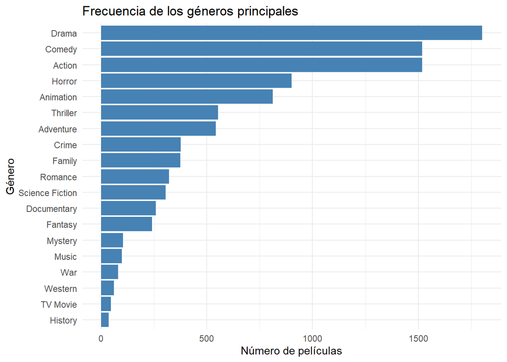

### 8.¿A qué género principal pertenecen las películas más largas?

Pertenecen a **drama**. NOTA: Se tomaron en cuenta únicamente las primeras 20 películas más largas.

| first_genre | count |
| --- | --- |
| Drama | 7 |
| Action | 5 |
| Documentary | 4 |
| Comedy | 1 |
| Crime | 1 |
| Music | 1 |
| War | 1 |

### ¿La cantidad de actores influye en los ingresos de las películas? ¿se han hecho películas con más actores en los últimos años?

Dada la gráfica de correlación, podemos concluir que la cantidad de actores no influye en los ingresos de las películas.  
No hay una relación directa que demiuestre sí se han hecho películas con más actores en los últimos años, sí que han habido algunas películas con muchos actores, pero no existe una realación que pruebe que en los últimos años se hacen películas con más actores.

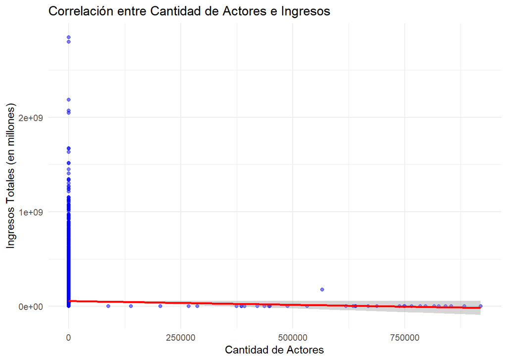

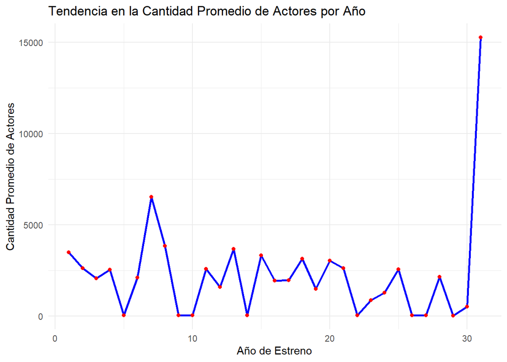

### 10. ¿Quiénes son los directores que hicieron las 20 películas mejor calificadas?

Directores de las 20 películas mejor calificadas

| director | voteAvg |
| --- | --- |
| Thomas Coven | 10.0 |
| Víctor Barba, Juan Olivares | 10.0 |
| Rebecca Sugar | 10.0 |
| Laurent Bouzereau | 10.0 |
| Kaku Arakawa | 10.0 |
| Christin Baker | 10.0 |
| Miguel Angel Zavala | 10.0 |
| Dave Bullock, Troy Adomitis, Victor Cook | 9.6 |
| Samuel Leong | 9.5 |
| Won Myeong-jun | 9.5 |
| Selena Quintanilla | 9.4 |
| Haruo Sotozaki | 9.3 |
| Haruo Sotozaki | 9.3 |
| Ulises Valencia | 9.2 |
| Kim Nam-joon, Jeon Jung-kook, Kim Tae-hyung, Park Ji-min, Jung Ho-seok, Kim Seok-jin, Min Yoon-gi | 9.2 |
| Park Jun-soo | 9.2 |
| Igor Kopylov | 9.2 |
| Park Jun-soo | 9.1 |
| Michael Goguen | 9.0 |
| Filip Ghiorghi | 9.0 |

### 12. ¿Se asocian ciertos meses de lanzamiento con mejores ingresos?

Al calcular el promedio de ingresos de las películas agrupadas por mes, podemos observar como las películas estrenadas en junio son la mejor recibidas, seguidas de mayo y julio, el próximo mes en que reciben nien a las películas es en diciembre.

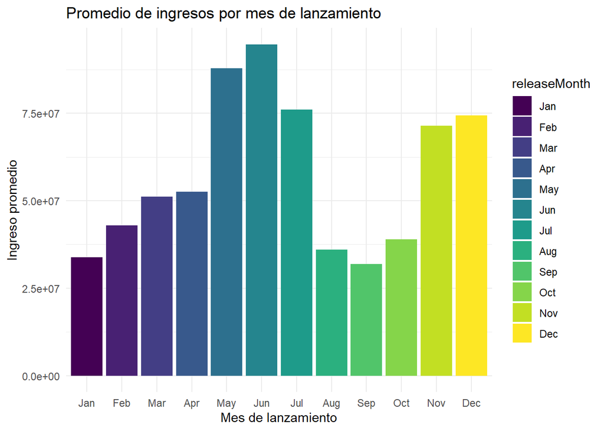

### 14.¿Cómo se correlacionan las calificaciones con el éxito comercial?

Existe una relación significativa entre las calificaciones y sus ingresos, pero esta relación no es definitiva ya que el modelo solo aplica un 2% de los ingresos, lo que nos dice que existen otras factores que definen el éxito comercial.

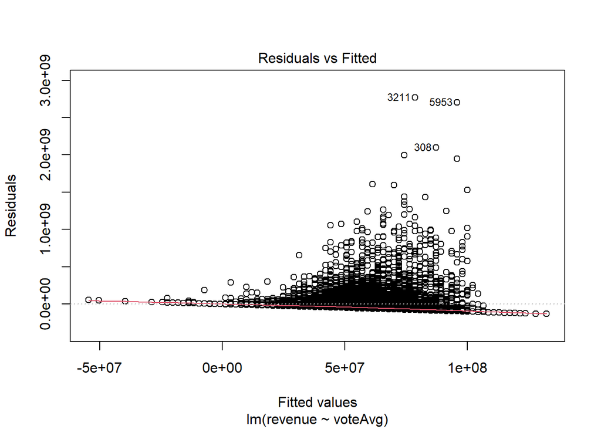

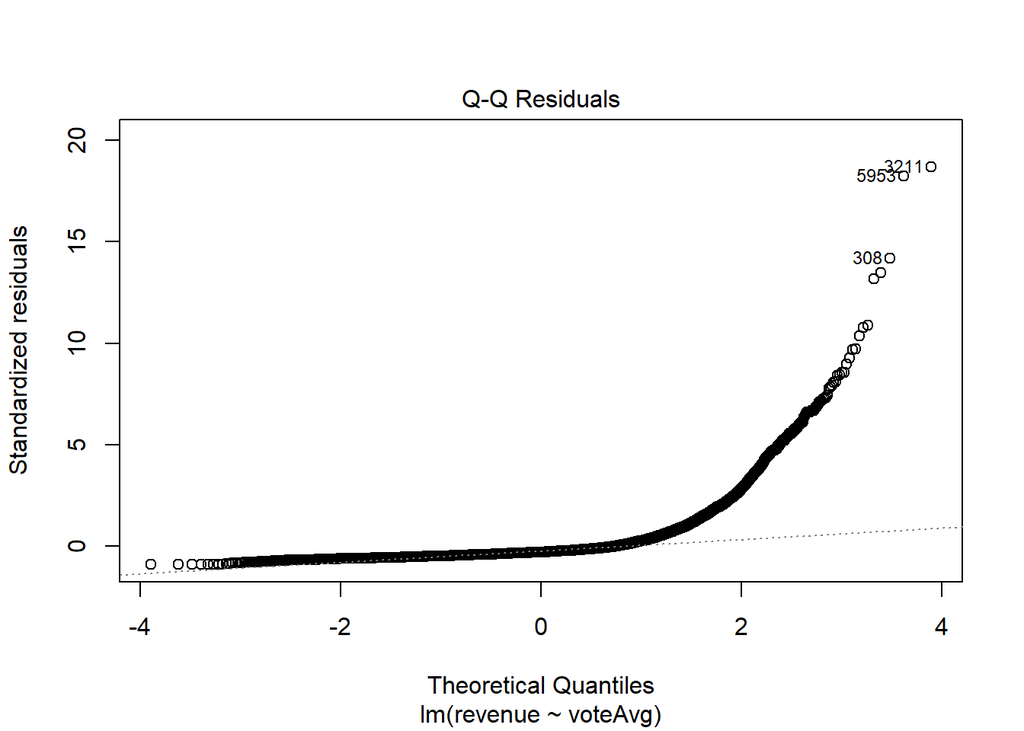

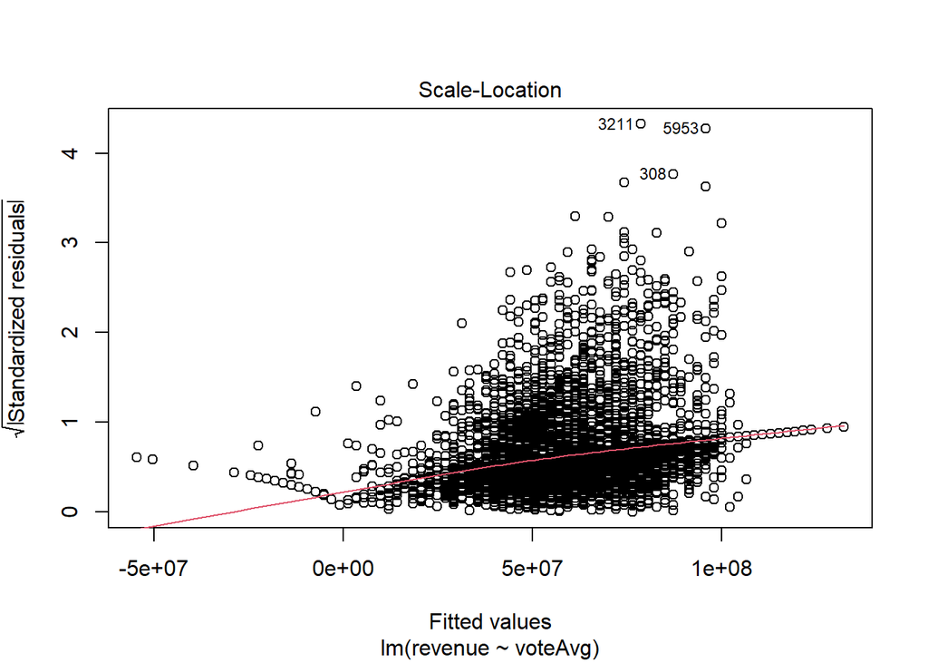

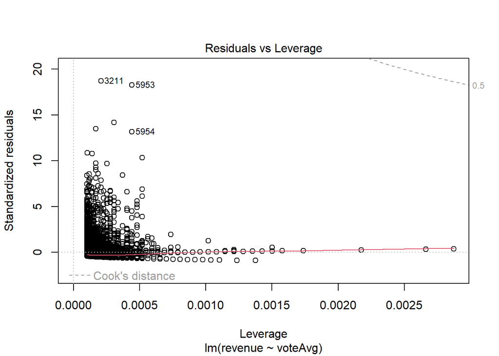

### 16. ¿Qué estrategias de marketing, como videos promocionales o páginas oficiales, generan mejores resultados?

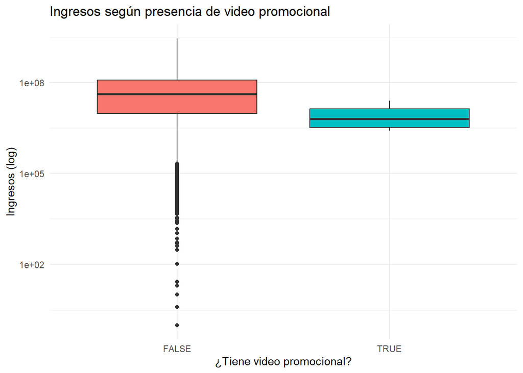

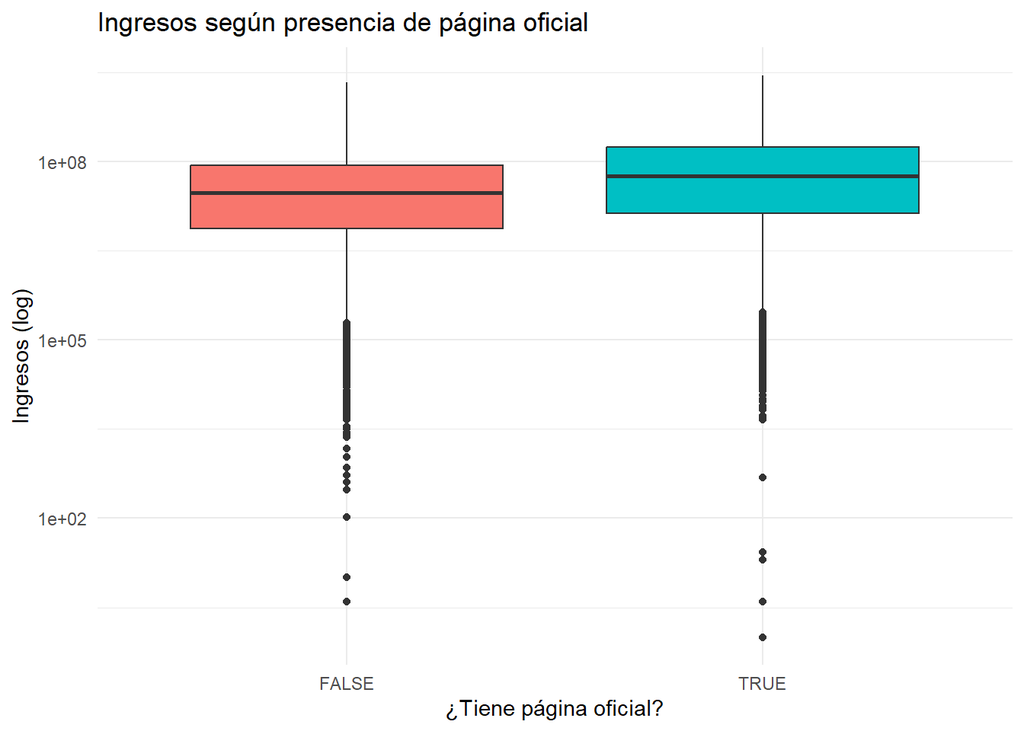

## Preguntas extras

### ¿Existe relación entre el prespuesto de la película y sus ingresos?

Los resultados indican una **relación positiva y moderadamente fuerte** entre el presupuesto de una película y sus ingresos. El **coeficiente de correlación de Pearson (0.757)** sugiere una asociación positiva considerable entre ambas variables. Además el **modelo de regresión lineal** muestra que en promedio por cada unidad adicional en el presupuesto los ingresos aumentan en **3.09 veces dicho valor**. Sin embargo, el **R² = 0.5737** indica que aproximadamente el **57.4% de la variabilidad en los ingresos** puede explicarse por el presupuesto, lo que sugiere que otros factores también influyen en el éxito de una película. En general el presupuesto es un buen predictor de los ingresos, pero no el único determinante del éxito financiero.

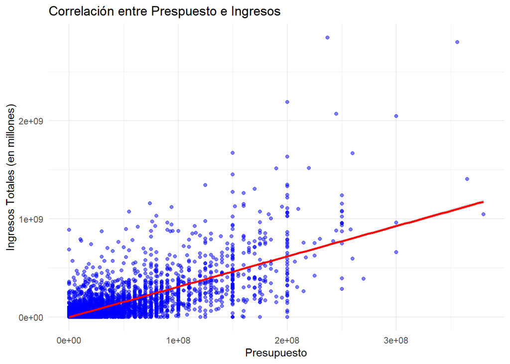

```
## [1] 0.7574542
```

```
##
## Call:
## lm(formula = revenue ~ budget, data = movies)
##
## Residuals:
##        Min         1Q     Median         3Q        Max
## -618034787  -13405091     650592     755710 2114754621
##
## Coefficients:
##               Estimate Std. Error t value Pr(>|t|)
## (Intercept) -6.506e+05  1.095e+06  -0.594    0.552
## budget       3.093e+00  2.667e-02 116.004   <2e-16 ***
## ---
## Signif. codes:  0 '***' 0.001 '**' 0.01 '*' 0.05 '.' 0.1 ' ' 1
##
## Residual standard error: 97670000 on 9998 degrees of freedom
## Multiple R-squared:  0.5737, Adjusted R-squared:  0.5737
## F-statistic: 1.346e+04 on 1 and 9998 DF,  p-value: < 2.2e-16
```

### ¿Cuál era el índice promedio de popularidad de los actores de las 10 películas más taquilleras?

10 películas con mayores ingresos

| title | avgpopularity | revenue |
| --- | --- | --- |
| Avatar | 6.55 | 2847246203 |
| Avengers: Endgame | 15.05 | 2797800564 |
| Titanic | 3.27 | 2187463944 |
| Star Wars: The Force Awakens | 4.11 | 2068223624 |
| Avengers: Infinity War | 17.21 | 2046239637 |
| Jurassic World | 6.41 | 1671713208 |
| The Lion King | 6.07 | 1667635327 |
| Spider-Man: No Way Home | 13.92 | 1631853496 |
| The Avengers | 5.28 | 1518815515 |
| Furious 7 | 10.10 | 1515047671 |

### En todo el dataset, ¿la cantidad de actores y actrices es igual?

No, el género que más abunda es el masculino.

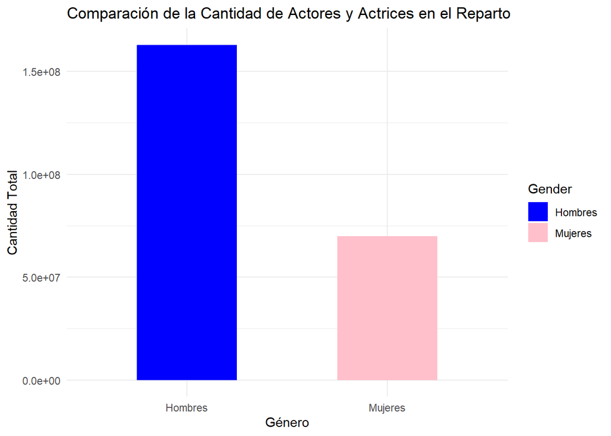